# ML-Lab 02 -23042022

```python
import numpy as np
import seaborn as sns
import pandas as pd
import matplotlib.pyplot as plt
sns.set(style='darkgrid')
```

```python
df = pd.read_csv('winequality-red.csv')
```

```python
df.head()
```

|  | fixed acidity | volatile acidity | citric acid | residual sugar | chlorides | free sulfur dioxide | total sulfur dioxide | density | pH | sulphates | alcohol | quality |
| --- | --- | --- | --- | --- | --- | --- | --- | --- | --- | --- | --- | --- |
| 0 | 7.4 | 0.70 | 0.00 | 1.9 | 0.076 | 11.0 | 34.0 | 0.9978 | 3.51 | 0.56 | 9.4 | 5 |
| 1 | 7.8 | 0.88 | 0.00 | 2.6 | 0.098 | 25.0 | 67.0 | 0.9968 | 3.20 | 0.68 | 9.8 | 5 |
| 2 | 7.8 | 0.76 | 0.04 | 2.3 | 0.092 | 15.0 | 54.0 | 0.9970 | 3.26 | 0.65 | 9.8 | 5 |
| 3 | 11.2 | 0.28 | 0.56 | 1.9 | 0.075 | 17.0 | 60.0 | 0.9980 | 3.16 | 0.58 | 9.8 | 6 |
| 4 | 7.4 | 0.70 | 0.00 | 1.9 | 0.076 | 11.0 | 34.0 | 0.9978 | 3.51 | 0.56 | 9.4 | 5 |

```python
df.columns
```

```
Index(['fixed acidity', 'volatile acidity', 'citric acid', 'residual sugar',
       'chlorides', 'free sulfur dioxide', 'total sulfur dioxide', 'density',
       'pH', 'sulphates', 'alcohol', 'quality'],
      dtype='object')
```

```python
df.shape
```

```
(1599, 12)
```

```python
df.isna().sum()
```

```
fixed acidity           0
volatile acidity        0
citric acid             0
residual sugar          0
chlorides               0
free sulfur dioxide     0
total sulfur dioxide    0
density                 0
pH                      0
sulphates               0
alcohol                 0
quality                 0
dtype: int64
```

```python
df.nunique()
```

```
fixed acidity            96
volatile acidity        143
citric acid              80
residual sugar           91
chlorides               153
free sulfur dioxide      60
total sulfur dioxide    144
density                 436
pH                       89
sulphates                96
alcohol                  65
quality                   6
dtype: int64
```

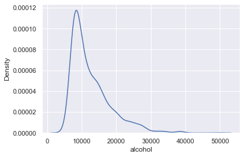

```python
sns.kdeplot(data=df, x= (df['alcohol']**4), multiple="layer") #kde=kernal density estimation
```

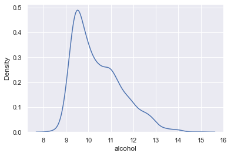

```python
sns.kdeplot(data=df, x= (df['alcohol']), multiple="layer")
```

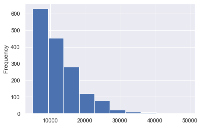

```python
(df['alcohol']**4).plot(kind='hist')
```

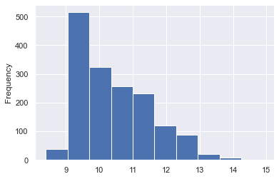

```python
(df['alcohol']).plot(kind='hist')
```

## To check for outliers

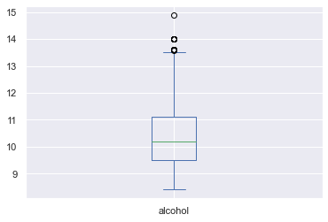

```python
df['alcohol'].plot(kind='box',grid=True)
```

#### Correlation matrix only for continuous columns

```python
co = df[['fixed acidity','volatile acidity','residual sugar',
       'chlorides','free sulfur dioxide','total sulfur dioxide', 'density','citric acid',
       'sulphates','pH', 'alcohol']]
```

```python
corr = co.corr()
corr.style.background_gradient(cmap='coolwarm')
```

|  | fixed acidity | volatile acidity | residual sugar | chlorides | free sulfur dioxide | total sulfur dioxide | density | citric acid | sulphates | pH | alcohol |
| --- | --- | --- | --- | --- | --- | --- | --- | --- | --- | --- | --- |
| fixed acidity | 1.000000 | -0.256131 | 0.114777 | 0.093705 | -0.153794 | -0.113181 | 0.668047 | 0.671703 | 0.183006 | -0.682978 | -0.061668 |
| volatile acidity | -0.256131 | 1.000000 | 0.001918 | 0.061298 | -0.010504 | 0.076470 | 0.022026 | -0.552496 | -0.260987 | 0.234937 | -0.202288 |
| residual sugar | 0.114777 | 0.001918 | 1.000000 | 0.055610 | 0.187049 | 0.203028 | 0.355283 | 0.143577 | 0.005527 | -0.085652 | 0.042075 |
| chlorides | 0.093705 | 0.061298 | 0.055610 | 1.000000 | 0.005562 | 0.047400 | 0.200632 | 0.203823 | 0.371260 | -0.265026 | -0.221141 |
| free sulfur dioxide | -0.153794 | -0.010504 | 0.187049 | 0.005562 | 1.000000 | 0.667666 | -0.021946 | -0.060978 | 0.051658 | 0.070377 | -0.069408 |
| total sulfur dioxide | -0.113181 | 0.076470 | 0.203028 | 0.047400 | 0.667666 | 1.000000 | 0.071269 | 0.035533 | 0.042947 | -0.066495 | -0.205654 |
| density | 0.668047 | 0.022026 | 0.355283 | 0.200632 | -0.021946 | 0.071269 | 1.000000 | 0.364947 | 0.148506 | -0.341699 | -0.496180 |
| citric acid | 0.671703 | -0.552496 | 0.143577 | 0.203823 | -0.060978 | 0.035533 | 0.364947 | 1.000000 | 0.312770 | -0.541904 | 0.109903 |
| sulphates | 0.183006 | -0.260987 | 0.005527 | 0.371260 | 0.051658 | 0.042947 | 0.148506 | 0.312770 | 1.000000 | -0.196648 | 0.093595 |
| pH | -0.682978 | 0.234937 | -0.085652 | -0.265026 | 0.070377 | -0.066495 | -0.341699 | -0.541904 | -0.196648 | 1.000000 | 0.205633 |
| alcohol | -0.061668 | -0.202288 | 0.042075 | -0.221141 | -0.069408 | -0.205654 | -0.496180 | 0.109903 | 0.093595 | 0.205633 | 1.000000 |

Fixed acidity and free sulfur dioxide needs to be removed.

Note: Scale of total sulfur is higher than others which may cause trouble.

```python
x = df[['volatile acidity','residual sugar',
       'chlorides','total sulfur dioxide', 'density','citric acid',
       'sulphates','pH']]
y = df['alcohol']
```

[output not shown]

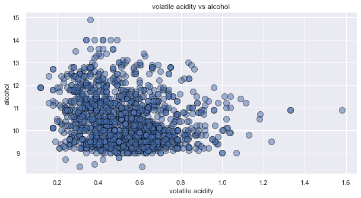

[output not shown]

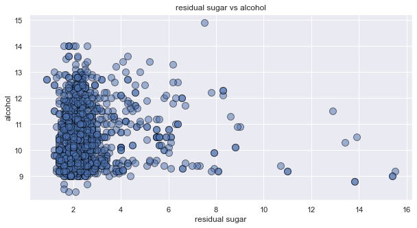

[output not shown]

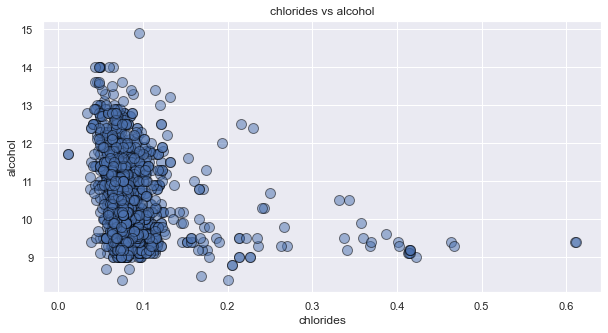

[output not shown]

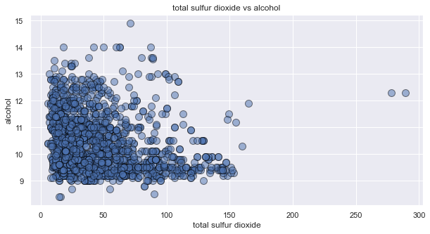

[output not shown]

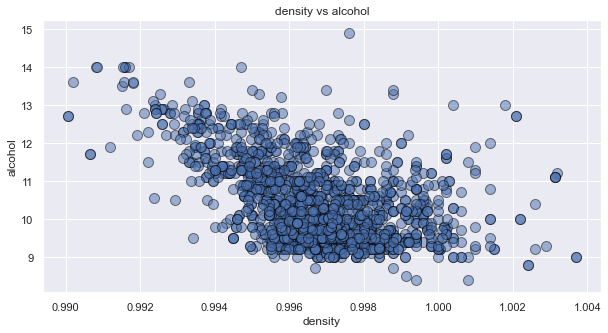

[output not shown]

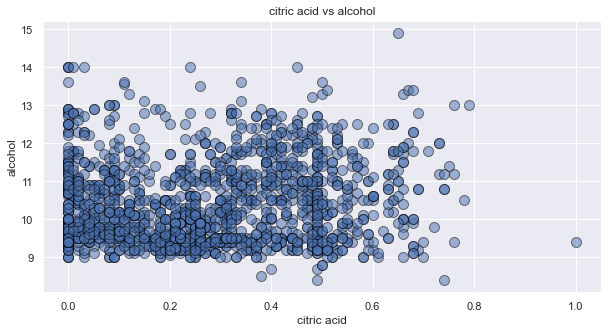

[output not shown]

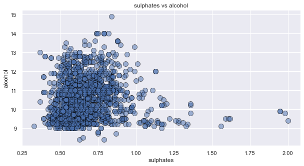

[output not shown]

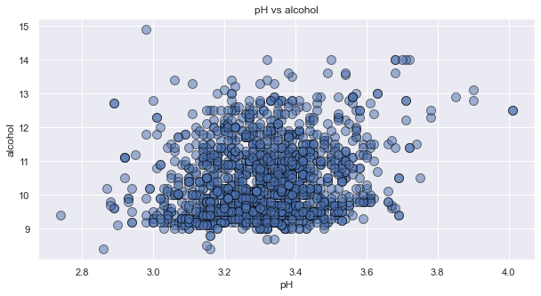

```python
for i in x:
    df[[i,'alcohol']].plot(x=i, y='alcohol', kind='scatter',edgecolor='black',alpha=0.5,s=100,figsize=(10,5))
    plt.title(f'{i} vs alcohol')
    plt.show()
```

```python
from sklearn.linear_model import LinearRegression
from sklearn.model_selection import train_test_split
import statsmodels.api as smf
import scipy.stats as stats
import warnings
warnings.filterwarnings("ignore")
from statsmodels.stats.outliers_influence import variance_inflation_factor
```

```python
x = df[['volatile acidity','residual sugar',
       'chlorides','total sulfur dioxide', 'density','citric acid',
       'sulphates','pH']]
y = df['alcohol']
```

```python
X_train, X_test, y_train, y_test = train_test_split(x, y, test_size=0.20, random_state=0)
```

### Using the ols model

```python
import statsmodels.api as smf
```

### To check for correlation

```python
X_train_corr = X_train.copy()
X_train_corr['alcohol'] = y_train
X_train_corr.corr().style.background_gradient(cmap = 'coolwarm')
```

|  | volatile acidity | residual sugar | chlorides | total sulfur dioxide | density | citric acid | sulphates | pH | alcohol |
| --- | --- | --- | --- | --- | --- | --- | --- | --- | --- |
| volatile acidity | 1.000000 | 0.009490 | 0.052602 | 0.082385 | 0.008826 | -0.549642 | -0.255571 | 0.257278 | -0.177555 |
| residual sugar | 0.009490 | 1.000000 | 0.074685 | 0.215481 | 0.376888 | 0.142106 | 0.014920 | -0.094356 | 0.020335 |
| chlorides | 0.052602 | 0.074685 | 1.000000 | 0.052407 | 0.201348 | 0.213882 | 0.366476 | -0.255225 | -0.206436 |
| total sulfur dioxide | 0.082385 | 0.215481 | 0.052407 | 1.000000 | 0.078787 | 0.028341 | 0.051698 | -0.070467 | -0.210060 |
| density | 0.008826 | 0.376888 | 0.201348 | 0.078787 | 1.000000 | 0.368571 | 0.153594 | -0.333858 | -0.493136 |
| citric acid | -0.549642 | 0.142106 | 0.213882 | 0.028341 | 0.368571 | 1.000000 | 0.315346 | -0.541419 | 0.105826 |
| sulphates | -0.255571 | 0.014920 | 0.366476 | 0.051698 | 0.153594 | 0.315346 | 1.000000 | -0.198172 | 0.097777 |
| pH | 0.257278 | -0.094356 | -0.255225 | -0.070467 | -0.333858 | -0.541419 | -0.198172 | 1.000000 | 0.199708 |
| alcohol | -0.177555 | 0.020335 | -0.206436 | -0.210060 | -0.493136 | 0.105826 | 0.097777 | 0.199708 | 1.000000 |

### To check multicollinearity

```python
Vif = pd.Series([variance_inflation_factor(x.values, i)
               for i in range(x.shape[1])],
              index=x.columns)
Vif
```

```
volatile acidity         15.588789
residual sugar            4.557348
chlorides                 5.787479
total sulfur dioxide      3.171246
density                 790.027741
citric acid               6.155201
sulphates                20.938016
pH                      669.592816
dtype: float64
```

### Simple Linear Regression with density and alcohol

```python
x_train, x_test, Y_train, Y_test = train_test_split(df['density'], df['alcohol'], test_size=0.20, random_state=0)
```

```python
reg = smf.OLS(Y_train,x_train)
r2 = reg.fit()
print(r2.summary())
```

```
                                 OLS Regression Results
=======================================================================================
Dep. Variable:                alcohol   R-squared (uncentered):                   0.990
Model:                            OLS   Adj. R-squared (uncentered):              0.990
Method:                 Least Squares   F-statistic:                          1.209e+05
Date:                Fri, 29 Apr 2022   Prob (F-statistic):                        0.00
Time:                        21:35:15   Log-Likelihood:                         -1902.2
No. Observations:                1279   AIC:                                      3806.
Df Residuals:                    1278   BIC:                                      3812.
Df Model:                           1
Covariance Type:            nonrobust
==============================================================================
                 coef    std err          t      P>|t|      [0.025      0.975]
------------------------------------------------------------------------------
density       10.4468      0.030    347.667      0.000      10.388      10.506
==============================================================================
Omnibus:                      127.404   Durbin-Watson:                   2.059
Prob(Omnibus):                  0.000   Jarque-Bera (JB):              165.275
Skew:                           0.871   Prob(JB):                     1.29e-36
Kurtosis:                       3.254   Cond. No.                         1.00
==============================================================================

Notes:
[1] R² is computed without centering (uncentered) since the model does not contain a constant.
[2] Standard Errors assume that the covariance matrix of the errors is correctly specified.
```

Since density has high correlation with alcohol, we discard this model

### To check for correlation

```python
X_train_corr = X_train.copy()
X_train_corr['alcohol'] = y_train
X_train_corr.corr().style.background_gradient(cmap = 'coolwarm')
```

|  | volatile acidity | residual sugar | chlorides | total sulfur dioxide | density | citric acid | sulphates | pH | alcohol |
| --- | --- | --- | --- | --- | --- | --- | --- | --- | --- |
| volatile acidity | 1.000000 | 0.009490 | 0.052602 | 0.082385 | 0.008826 | -0.549642 | -0.255571 | 0.257278 | -0.177555 |
| residual sugar | 0.009490 | 1.000000 | 0.074685 | 0.215481 | 0.376888 | 0.142106 | 0.014920 | -0.094356 | 0.020335 |
| chlorides | 0.052602 | 0.074685 | 1.000000 | 0.052407 | 0.201348 | 0.213882 | 0.366476 | -0.255225 | -0.206436 |
| total sulfur dioxide | 0.082385 | 0.215481 | 0.052407 | 1.000000 | 0.078787 | 0.028341 | 0.051698 | -0.070467 | -0.210060 |
| density | 0.008826 | 0.376888 | 0.201348 | 0.078787 | 1.000000 | 0.368571 | 0.153594 | -0.333858 | -0.493136 |
| citric acid | -0.549642 | 0.142106 | 0.213882 | 0.028341 | 0.368571 | 1.000000 | 0.315346 | -0.541419 | 0.105826 |
| sulphates | -0.255571 | 0.014920 | 0.366476 | 0.051698 | 0.153594 | 0.315346 | 1.000000 | -0.198172 | 0.097777 |
| pH | 0.257278 | -0.094356 | -0.255225 | -0.070467 | -0.333858 | -0.541419 | -0.198172 | 1.000000 | 0.199708 |
| alcohol | -0.177555 | 0.020335 | -0.206436 | -0.210060 | -0.493136 | 0.105826 | 0.097777 | 0.199708 | 1.000000 |

After checking the correlation matrix, we can consider the total sulfur dioxide

```python
x_train, x_test, Y_train, Y_test = train_test_split(df['total sulfur dioxide'], df['alcohol'], test_size=0.20, random_state=0)
```

```python
r1 = smf.OLS(Y_train,x_train)
r2 = r1.fit()
print(r2.summary())
```

```
                                 OLS Regression Results
=======================================================================================
Dep. Variable:                alcohol   R-squared (uncentered):                   0.637
Model:                            OLS   Adj. R-squared (uncentered):              0.636
Method:                 Least Squares   F-statistic:                              2239.
Date:                Fri, 29 Apr 2022   Prob (F-statistic):                   3.57e-283
Time:                        21:35:15   Log-Likelihood:                         -4171.0
No. Observations:                1279   AIC:                                      8344.
Df Residuals:                    1278   BIC:                                      8349.
Df Model:                           1
Covariance Type:            nonrobust
========================================================================================
                           coef    std err          t      P>|t|      [0.025      0.975]
----------------------------------------------------------------------------------------
total sulfur dioxide     0.1444      0.003     47.313      0.000       0.138       0.150
==============================================================================
Omnibus:                      306.163   Durbin-Watson:                   1.349
Prob(Omnibus):                  0.000   Jarque-Bera (JB):              710.913
Skew:                          -1.303   Prob(JB):                    4.24e-155
Kurtosis:                       5.559   Cond. No.                         1.00
==============================================================================

Notes:
[1] R² is computed without centering (uncentered) since the model does not contain a constant.
[2] Standard Errors assume that the covariance matrix of the errors is correctly specified.
```

Since total sulfur dioxide has significant correlation with alcohol, we discard this model

Looking at the correlation matrix again, we can consider taking the residual sugar to predict alcohol

```python
x_train, x_test, Y_train, Y_test = train_test_split(df['residual sugar'], df['alcohol'], test_size=0.20, random_state=0)
```

```python
r1 = smf.OLS(Y_train,x_train)
r2 = r1.fit()
print(r2.summary())
```

```
                                 OLS Regression Results
=======================================================================================
Dep. Variable:                alcohol   R-squared (uncentered):                   0.750
Model:                            OLS   Adj. R-squared (uncentered):              0.749
Method:                 Least Squares   F-statistic:                              3826.
Date:                Fri, 29 Apr 2022   Prob (F-statistic):                        0.00
Time:                        21:35:16   Log-Likelihood:                         -3932.7
No. Observations:                1279   AIC:                                      7867.
Df Residuals:                    1278   BIC:                                      7873.
Df Model:                           1
Covariance Type:            nonrobust
==================================================================================
                     coef    std err          t      P>|t|      [0.025      0.975]
----------------------------------------------------------------------------------
residual sugar     3.0857      0.050     61.857      0.000       2.988       3.184
==============================================================================
Omnibus:                     1221.251   Durbin-Watson:                   1.549
Prob(Omnibus):                  0.000   Jarque-Bera (JB):            49677.424
Skew:                          -4.499   Prob(JB):                         0.00
Kurtosis:                      32.175   Cond. No.                         1.00
==============================================================================

Notes:
[1] R² is computed without centering (uncentered) since the model does not contain a constant.
[2] Standard Errors assume that the covariance matrix of the errors is correctly specified.
```

```python
predictions = r2.predict(x_train)
predictions
```

```
642      7.097094
679     10.182787
473      6.479955
390      4.319970
1096    16.971311
          ...
763      6.171386
835      4.628539
1216     6.171386
559     13.268480
684      7.097094
Length: 1279, dtype: float64
```

To check whether the residuals are normally distributed

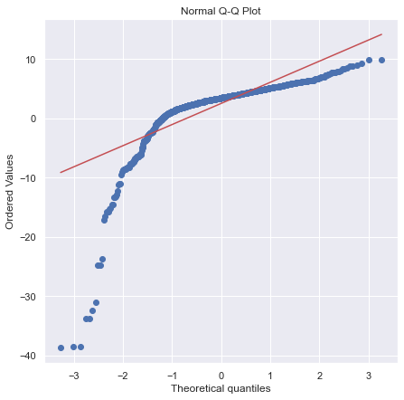

```python
residuals = Y_train - predictions
residuals

plt.figure(figsize=(7,7))
stats.probplot(residuals, dist="norm", plot=plt)
plt.title("Normal Q-Q Plot")
```

To test for normality: Shapiro Wilk Test

Ho: The residuals follow normal distribution

H1: The residuals do not follow normal distribution

```python
from scipy.stats import shapiro
shapiro(residuals)
```

```
ShapiroResult(statistic=0.6040308475494385, pvalue=0.0)
```

This implies that the residuals are not normally distributed.

## Multiple linear regression

## MLR using Sklearn

```python
x = df[['volatile acidity','residual sugar',
       'chlorides','total sulfur dioxide', 'density','citric acid',
       'sulphates','pH']]
y = df['alcohol']
```

```python
X_train, X_test, y_train, y_test = train_test_split(x, y, test_size=0.20, random_state=0)
```

```python
model = LinearRegression()
```

```python
model.fit(X_train,y_train)
```

```
LinearRegression()
```

```python
model.intercept_
```

```
388.79412020313833
```

```python
model.coef_
```

```
array([ 6.93947365e-01,  2.11840387e-01, -4.71455477e+00, -7.19621825e-03,
       -3.85793018e+02,  2.57659083e+00,  1.26088090e+00,  1.35061205e+00])
```

```python
model.score(X_train, y_train)
```

```
0.5235152892536867
```

```python
predictions = model.predict(x)
predictions
```

```
array([ 9.58187076,  9.63228315,  9.67641084, ..., 10.73928232,
       10.97589756, 11.7224154 ])
```

1. To validate the assumptions of linearity

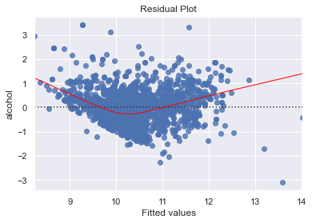

```python
sns.residplot(predictions,'alcohol',data=df,lowess=True,
             line_kws = {'color':'red','lw':1,'alpha':1})
plt.xlabel("Fitted values")
plt.title("Residual Plot")
```

1. QQ Plot - To check whether the residuals are normally distributed

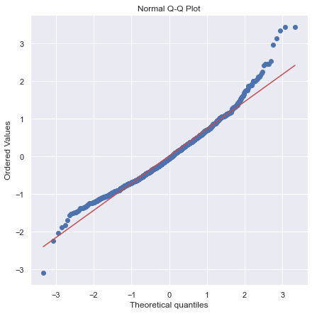

```python
residuals = y - predictions
residuals

plt.figure(figsize=(7,7))
stats.probplot(residuals, dist="norm", plot=plt)
plt.title("Normal Q-Q Plot")
```

1. Scale-Location plot - To check homoscedasticity

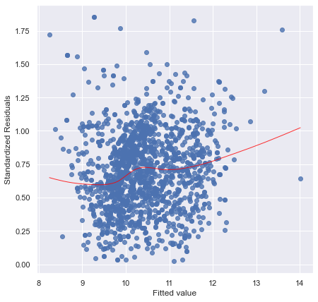

```python
model_norm = np.sqrt(np.abs(residuals))

plt.figure(figsize=(7,7))
sns.regplot(predictions,model_norm,scatter=True,lowess=True,line_kws={'color': 'red', 'lw': 1, 'alpha': 0.8})
plt.ylabel("Standardized Residuals")
plt.xlabel("Fitted value")
```

1. To check for multicollinearity

```python
Vif = pd.Series([variance_inflation_factor(X_train.values, i)
               for i in range(X_train.shape[1])],
              index=x.columns)
Vif
```

```
volatile acidity         14.971299
residual sugar            4.423500
chlorides                 5.552125
total sulfur dioxide      3.166102
density                 777.099489
citric acid               6.046424
sulphates                19.644814
pH                      667.410669
dtype: float64
```

Density and pH has high variance inflation factor, which means it has greater correlation with other variables, and hence they have to be removed

```python
x = df[['volatile acidity','residual sugar',
       'chlorides','total sulfur dioxide','citric acid',
       'sulphates']]
y = df['alcohol']
```

```python
X_train, X_test, y_train, y_test = train_test_split(x, y, test_size=0.20, random_state=0)
```

```python
model = LinearRegression()
```

```python
model.fit(X_train,y_train)
```

```
LinearRegression()
```

```python
predictions = model.predict(x)
predictions
```

```
array([10.26483132, 10.00017653, 10.13819405, ..., 10.56188501,
       10.42935765, 10.78787213])
```

1. To validate the assumptions of linearity

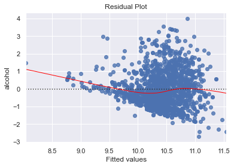

```python
sns.residplot(predictions,'alcohol',data=df,lowess=True,
             line_kws = {'color':'red','lw':1,'alpha':1})
plt.xlabel("Fitted values")
plt.title("Residual Plot")
```

1. QQ Plot - To check whether the residuals are normally distributed

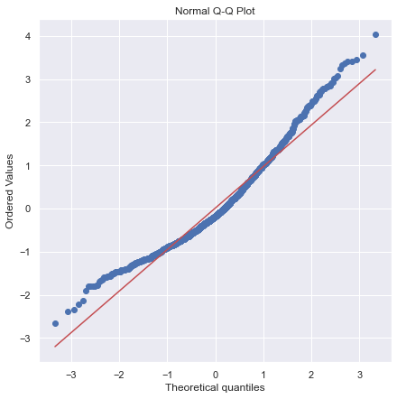

```python
residuals = y - predictions
residuals

plt.figure(figsize=(7,7))
stats.probplot(residuals, dist="norm", plot=plt)
plt.title("Normal Q-Q Plot")
```

1. Scale-Location plot - To check homoscedasticity

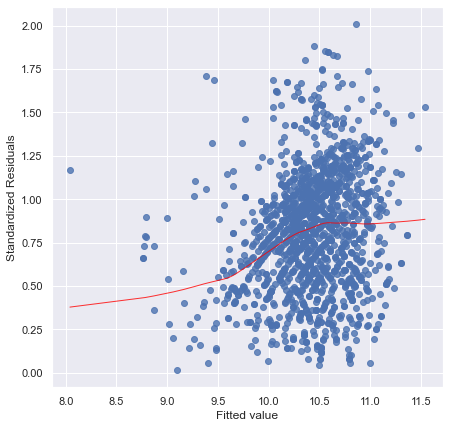

```python
model_norm = np.sqrt(np.abs(residuals))

plt.figure(figsize=(7,7))
sns.regplot(predictions,model_norm,scatter=True,lowess=True,line_kws={'color': 'red', 'lw': 1, 'alpha': 0.8})
plt.ylabel("Standardized Residuals")
plt.xlabel("Fitted value")
```

1. To check for multicollinearity

```python
Vif = pd.Series([variance_inflation_factor(X_train.values, i)
               for i in range(X_train.shape[1])],
              index=x.columns)
Vif
```

```
volatile acidity         6.994933
residual sugar           4.278715
chlorides                5.317275
total sulfur dioxide     3.145403
citric acid              4.064464
sulphates               11.776680
dtype: float64
```

This is a better model compared to the other model

## Multiple Linear Regression using OLS

```python
a = df[['volatile acidity','residual sugar',
       'chlorides','total sulfur dioxide','citric acid',
       'sulphates']]
b = df['alcohol']
```

```python
A_train, A_test, b_train, b_test = train_test_split(a, b, test_size=0.20, random_state=0)
```

```python
e = smf.OLS(b_train,A_train)
e1 = e.fit()
print(e1.summary())
```

```
                                 OLS Regression Results
=======================================================================================
Dep. Variable:                alcohol   R-squared (uncentered):                   0.966
Model:                            OLS   Adj. R-squared (uncentered):              0.966
Method:                 Least Squares   F-statistic:                              6049.
Date:                Fri, 29 Apr 2022   Prob (F-statistic):                        0.00
Time:                        21:35:19   Log-Likelihood:                         -2653.8
No. Observations:                1279   AIC:                                      5320.
Df Residuals:                    1273   BIC:                                      5350.
Df Model:                           6
Covariance Type:            nonrobust
========================================================================================
                           coef    std err          t      P>|t|      [0.025      0.975]
----------------------------------------------------------------------------------------
volatile acidity         7.9493      0.255     31.195      0.000       7.449       8.449
residual sugar           0.2649      0.038      6.965      0.000       0.190       0.340
chlorides              -11.2656      1.254     -8.981      0.000     -13.727      -8.805
total sulfur dioxide    -0.0038      0.002     -2.301      0.022      -0.007      -0.001
citric acid              4.6248      0.325     14.235      0.000       3.987       5.262
sulphates                7.8368      0.272     28.832      0.000       7.304       8.370
==============================================================================
Omnibus:                      168.483   Durbin-Watson:                   2.045
Prob(Omnibus):                  0.000   Jarque-Bera (JB):              482.632
Skew:                          -0.681   Prob(JB):                    1.58e-105
Kurtosis:                       5.683   Cond. No.                     1.35e+03
==============================================================================

Notes:
[1] R² is computed without centering (uncentered) since the model does not contain a constant.
[2] Standard Errors assume that the covariance matrix of the errors is correctly specified.
[3] The condition number is large, 1.35e+03. This might indicate that there are
strong multicollinearity or other numerical problems.
```

```python
prediction = e1.predict(a)
prediction
```

```
0        9.470756
1       11.653924
2       10.687544
3        8.790918
4        9.470756
          ...
1594     9.033228
1595    10.480642
1596    10.133730
1597    10.763710
1598     9.849180
Length: 1599, dtype: float64
```

1. To validate the assumptions of linearity

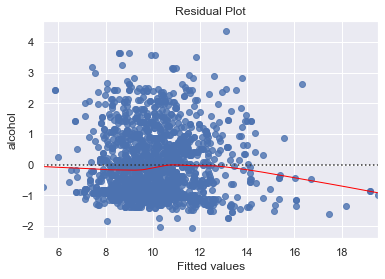

```python
sns.residplot(prediction,'alcohol',data=df,lowess=True,
             line_kws = {'color':'red','lw':1,'alpha':1})
plt.xlabel("Fitted values")
plt.title("Residual Plot")
```

1. QQ Plot - To check whether the residuals are normally distributed

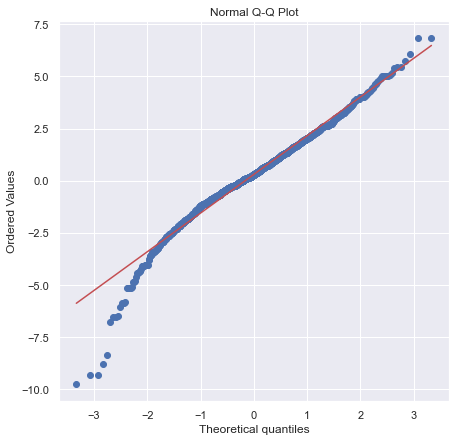

```python
residual = y - prediction
residual

plt.figure(figsize=(7,7))
stats.probplot(residual, dist="norm", plot=plt)
plt.title("Normal Q-Q Plot")
```

1. Scale-Location plot - To check homoscedasticity

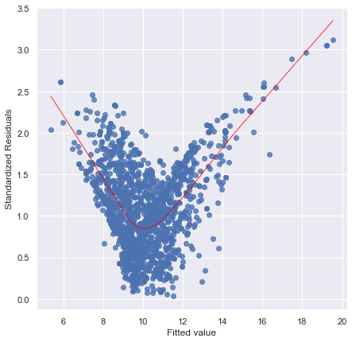

```python
model_norm = np.sqrt(np.abs(residual))

plt.figure(figsize=(7,7))
sns.regplot(prediction,model_norm,scatter=True,lowess=True,line_kws={'color': 'red', 'lw': 1, 'alpha': 0.8})
plt.ylabel("Standardized Residuals")
plt.xlabel("Fitted value")
```

1. To check for multicollinearity

```python
Vif = pd.Series([variance_inflation_factor(A_train.values, i)
               for i in range(A_train.shape[1])],
              index=x.columns)
Vif
```

```
volatile acidity         6.994933
residual sugar           4.278715
chlorides                5.317275
total sulfur dioxide     3.145403
citric acid              4.064464
sulphates               11.776680
dtype: float64
```